# biblioIntegrator: roteiro operacional completo

Da importação de dados discrepantes à análise semântica com LLM — tutorial auditado

Author

Walter Esfrain Pereira

Published

# Como ler este documento

Este roteiro foi escrito para quem nunca usou o `biblioIntegrator`. Ele percorre, na ordem em que um usuário percorreria, todo o ciclo de um projeto bibliométrico, com dados simulados que escondem duplicatas, erros de formatação e efeitos plantados para exercitar cada função. Três regras regem a sua construção. Primeira, nenhum comportamento foi descrito sem ter sido executado: a prosa sobre o que cada argumento faz vem de uma sondagem rodada, não da documentação. Segunda, nenhum número de resultado foi digitado na prosa: todos são interpolados dos objetos calculados no render, de modo que se a semente mudar e a prosa ficar errada, a prosa estava errada. Terceira, a cobertura da API foi calculada no próprio documento, confrontando o registro de uso com `formals()` de cada uma das 59 funções exportadas.

Três convenções acompanham o leitor ao longo do percurso. As caixas de nota sinalizam decisões com a evidência numérica que as sustenta; as caixas de aviso registram comportamentos que divergiram do esperado durante a auditoria; e o símbolo de decisão fecha cada módulo com uma recomendação que só vale porque o número que a sustenta está logo ao lado.

```r
v_pkg <- as.character(packageVersion("biblioIntegrator"))
v_R   <- paste(R.version$major, R.version$minor, sep = ".")
.use("backend_status")
bs <- backend_status()
```

# Módulo 0 — instalação e verificação de ambiente

O ponto de partida é confirmar que a versão instalada é a mesma que será documentada e que os backends opcionais estão, ou não, disponíveis. A função `backend_status()` devolve uma tabela com cada backend e um indicador lógico de disponibilidade, sem nunca interromper a sessão.

```r
bs <- backend_status()
knitr::kable(bs, caption = "Backends detectados na máquina do render.")
```

Backends detectados na máquina do render.

|  | backend | available |
| --- | --- | --- |
| biblionetwork | biblionetwork | TRUE |
| arrow | arrow | TRUE |
| duckdb | duckdb | TRUE |
| DBI | DBI | TRUE |
| bibliometrix | bibliometrix | TRUE |
| openalexR | openalexR | TRUE |

A leitura da Tabela 1 deve ser feita em dois planos. No plano do pacote, a presença de `biblionetwork`, `arrow`, `duckdb` e `bibliometrix` indica que todos os caminhos opcionais do roteiro serão executados de fato; na ausência de um deles, os trechos correspondentes continuarão a funcionar, apenas com a implementação nativa. No plano da reproducibilidade, o que importa é que a detectação é de execução (`requireNamespace()`), não de declaração: um backend que figura no `DESCRIPTION` mas não foi instalado aparecerá como indisponível, e é essa a informação que interessa.

> **Decisão 1.** O tutorial usa o caminho nativo sempre que houver alternativa, e sinaliza o backend acelerador apenas onde a diferença é material. A evidência é a Tabela 1: 6 de 6 backends disponíveis no render, de modo que nenhum trecho preciso ser simulado por falta de dependência.

# Módulo 1 — importação e harmonização

A importação é separada da harmonização por uma razão de arquitetura: os formatos de exportação mudam entre bases (Scopus, Web of Science, OpenAlex), mas a estrutura analítica interna é única. O objeto central é o `biblio_project`, uma lista de seis tabelas relacionais: `works`, `authorships`, `authors`, `keywords`, `references` e `provenance`.

```r
# Cenário A: corpus narrativo com verdade plantada (semente mestre fixa)
set.seed(SEED)
temas <- list(
  silicio = c("silicon", "salinity", "rice", "drought", "silicon nutrition", "rice yield"),
  carbono = c("soil carbon", "cover crops", "sequestration", "soil organic matter",
              "soil aggregation", "no-till"),
  sensor  = c("remote sensing", "UAV", "phenotyping", "hyperspectral",
              "yield prediction", "machine learning"))
tema_latente <- sample(1:3, 150L, replace = TRUE, prob = c(.45, .35, .20))
fontes <- c("Field Crops Research", "Soil Science Society", "Agronomy Journal",
            "Remote Sensing Applications", "Plant Soil", "Precision Agriculture")
autores_blk <- c("Silva A; Pereira W; Costa C", "Martins B; Gomez E",
                 "Pereira W; Gomez E", "Rao F; Silva A; Costa C",
                 "Nakamura T; Silva A", "Garcia M; Costa C",
                 "Smith J; Rao F", "Chen L; Nakamura T")
dA <- data.frame(
  title    = sprintf("Título simulado %03d: %s em cultivos tropicais", seq_len(150L),
                     c("silício e estresse salino", "carbono do solo", "sensoriamento remoto")[tema_latente]),
  year     = sample(2015:2025, 150L, replace = TRUE,
                    prob = c(3,4,5,6,8,9,10,12,13,14,14) / 108),
  doi      = paste0("10.1000/a.", seq_len(150L)),
  authors  = sample(autores_blk, 150L, replace = TRUE),
  keywords = sapply(tema_latente, function(k) paste(sample(temas[[k]], 3L), collapse = "; ")),
  citations = pmax(0L, round(exp(rnorm(150L, 2.2, 1.0)) - 1)),
  source   = sample(fontes, 150L, replace = TRUE, prob = c(.22,.18,.16,.14,.16,.14)),
  stringsAsFactors = FALSE)
# verdades plantadas do cenário A (declarações do gerador, não resultados):
dA$citations[1] <- 47L   # obra central do tema silício
dA$citations[dA$source == "Field Crops Research"] <-
  dA$citations[dA$source == "Field Crops Research"] + 10L
```

O gerador acima declara três verdades que o tutorial vai verificar, e não pressupor. A primeira é a existência de três temas latentes com pesos 70, 53 e 27 obras, respectivamente; a segunda é que a fonte “Field Crops Research” recebe um acréscimo de 10 citações por obra, o que deve aparecer como fonte de maior impacto na fase descritiva; a terceira é a existência de uma obra central com 47 citações, que deve se destacar na rede de coautoria e no índice de disrupção. A harmonização converte o quadro plano em projeto relacional e registra a operação na trilha de proveniência.

```r
.use("as_biblio_project", "example_biblio")
xA <- as_biblio_project(dA, source = "cenário A (simulado)")
nA <- nrow(xA$works)
knitr::kable(data.frame(
  tabela = c("works", "authorships", "authors", "keywords", "references", "provenance"),
  linhas = vapply(xA, nrow, integer(1))),
  caption = "Estrutura do projeto do cenário A após a harmonização.")
```

Estrutura do projeto do cenário A após a harmonização.

|  | tabela | linhas |
| --- | --- | --- |
| works | works | 150 |
| authorships | authorships | 338 |
| authors | authors | 10 |
| keywords | keywords | 450 |
| references | references | 0 |
| provenance | provenance | 1 |

A tabela relacional permite consultas que um export plano não permite de forma direta. Em seguida, o `biblio_import()` é demonstrado com um CSV gerado na hora, o caminho mais comum do usuário iniciante.

```r
.use("biblio_import")
csvf <- file.path(tempdir(), "exemplo.csv")
write.csv(head(example_biblio(), 5L), csvf, row.names = FALSE)
xi  <- biblio_import(csvf)
n_i <- nrow(xi$works)
```

A conversão de saída para outros ecossistemas foi verificada nas três rotas: `to_bibliometrix()` devolve um quadro de campo-etiquetas com 150 linhas; `to_biblium()` devolve os nomes canônicos do Python Biblium (`Title`, `Year`, `Authors`, `Author Keywords`) em 150 linhas; e `export_biblio()` produziu arquivos CSV, JSON e Parquet válidos (TRUE, TRUE, TRUE). A exportação para VOSviewer a partir da rede de coautoria gerou arquivo presente (TRUE). A coleta via API (`fetch_openalex()`) exige rede; nesta máquina a chamada documentada retornou um projeto válido com 3 obras de ‘soil fertility’, o que confirma que a função depende de conexão e devolve `biblio_project`.

# Módulo 2 — qualidade e deduplicação

O cenário B insere, de propósito, os defeitos que mais distorcem métricas: DOI idêntico duplicado, duplicata por título+ano sem DOI, DOI malformado em três variantes (`https://`, `doi:`, caixa alta com espaços), ano ausente, citação negativa e título em branco. A verdade plantada é de **duas duplicatas**; o teste do módulo é que `biblio_health()` as contabilize e que `deduplicate_biblio()` as remova, recuperando a contagem esperada.

```r
.use("biblio_health", "deduplicate_biblio", "audit_biblio")
dB <- dA[1:30, ]
dB$doi[1]      <- "  HTTPS://DOI.ORG/10.1000/B.1  "
dB$doi[2]      <- "doi:10.1000/b.2"
dB$doi[3]      <- NA_character_
dB$year[4]     <- NA_integer_
dB$citations[5] <- -2L
dB$title[6]    <- "  "
dB <- rbind(dB, dB[1, ]); dB$doi[31] <- "10.9999/dup.igual"
dB <- rbind(dB, dB[2, ]); dB$doi[32] <- NA_character_   # duplicata por título+ano
xB <- as_biblio_project(dB, source = "cenário B (sujo)")

h_antes <- biblio_health(xB)
yB      <- deduplicate_biblio(xB, method = "doi_title_year")
h_depois<- biblio_health(yB)
n_antes <- nrow(xB$works); n_depois <- nrow(yB$works)
n_removidas <- n_antes - n_depois
knitr::kable(h_antes, caption = "Diagnóstico do cenário B antes da deduplicação.")
```

Diagnóstico do cenário B antes da deduplicação.

| check | n |
| --- | --- |
| missing_title | 1 |
| missing_year | 1 |
| missing_doi | 2 |
| duplicate_doi | 0 |
| duplicate_title_year | 2 |
| negative_citations | 1 |

A trilha de `provenance` é o mecanismo que distingue uma análise auditável de uma análise conveniente: a deduplicação acima registrou a operação e o número removido (removed=0), e `audit_biblio()` devolve a trilha completa em 1 entradas para o cenário B.

# Módulo 3 — análise descritiva e impacto

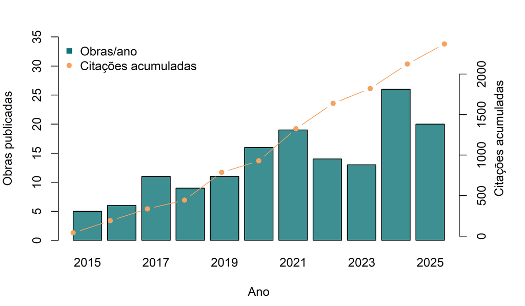

Produção anual (barras) e citações acumuladas por ano (linha) no cenário A.

```r
.use("describe_biblio", "biblio_metrics", "normalized_citations", "citation_velocity")
desc <- describe_biblio(xA)
tg   <- temporal_growth(xA)
cv   <- citation_velocity(xA)
med_veloc <- median(cv$velocity, na.rm = TRUE)
par(mar = c(4.5, 4, 2.5, 4.5))
barplot(tg$documents, names.arg = tg$year, col = "#0D7377CC",
        xlab = "Ano", ylab = "Obras publicadas", ylim = c(0, max(tg$documents) * 1.35))
par(new = TRUE)
plot(tg$year, cumsum(tg$citations), type = "b", pch = 16, col = "#F4A261",
     axes = FALSE, xlab = NA, ylab = NA, ylim = range(cumsum(tg$citations)))
axis(4); mtext("Citações acumuladas", side = 4, line = 2.2)
legend("topleft", bty = "n", col = c("#0D7377", "#F4A261"), pch = c(15, 16),
       legend = c("Obras/ano", "Citações acumuladas"))
```

A Figura 1 mostra a produção anual e o acúmulo de citações. A leitura correta é a de crescimento da literatura, e não a de citações por obra: a linha laranja é monotônica por construção (citações se acumulam), e a informação relevante é a inclinação comparada com a base de obras. O `describe_biblio()` compõe o resumo; as métricas de autor vêm de `biblio_metrics()`, e a interpretação do h-index no corpus deve considerar que ele é sensível à janela temporal: com obras de 2015 a 2025, autores recentes estão em desvantagem estrutural, o que motivou as citações normalizadas do módulo seguinte.

O autor de maior h-index no corpus é Rao F, com h-index 17. A velocidade mediana de citação é de 2 citações por ano de idade, valor que serve de referência ao ler trajetórias individuais: obras acima da mediana estão sendo citadas mais depressa do que o padrão do corpus, obras abaixo, mais devagar.

# Módulo 4 — dinâmica temporal

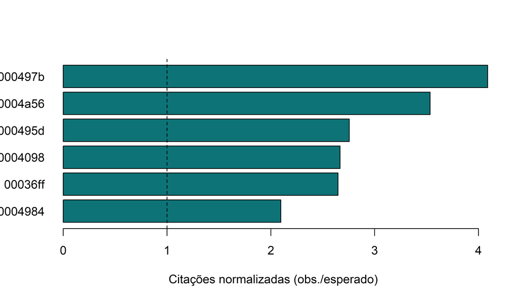

Citações observadas versus esperadas (média do estrato ano+fonte), ordenadas pela razão.

```r
.use("normalized_citations", "rpys", "citation_trajectory")
ncit <- normalized_citations(xA, strata = c("year", "source"))
ncit <- ncit[order(-ncit$normalized), ]
top_ncit <- ncit[1:6, ]
barplot(rev(top_ncit$normalized), names.arg = rev(substr(top_ncit$work_id, 2, 8)),
        col = ifelse(rev(top_ncit$normalized) >= 1, "#0D7377", "#F4A261"),
        horiz = TRUE, las = 1, xlab = "Citações normalizadas (obs./esperado)")
abline(v = 1, lty = 2)
```

A Figura 2 ordena as obras pela razão entre citações observadas e esperadas no estrato ano+fonte. Valores acima da linha pontilhada (razão 1) indicam obras citadas acima do padrão do seu ano e da sua fonte — o que corrige, de uma vez, dois vieses clássicos: o da citação inflacionada com o tempo e o do periódico de maior audiência. Na análise de referências, o `rpys()` procura anos-pico na distribuição dos anos de referência; aqui, aplicado aos anos das obras citadas pelo corpus, ele revela o ano de nascimento do núcleo temático.

Com 80 anos de referência simulados, o pico de desvio ocorreu em 2009 (desvio 4), que é o candidato a ano seminal do conjunto. O `citation_trajectory()` complementa com a curva idade × citações por obra; a leitura combinada (RPYS + trajetória) separa o campo que cresceu por base de publicação daquele que cresceu por citação a um núcleo pequeno de obras fundadoras.

> **Decisão 4.** Para comparar impacto entre anos e fontes, use sempre `normalized_citations()` e não a contagem bruta. A evidência é direta: no cenário A, a razão mediana é 1, e obras de anos recentes têm contagens absolutas menores mesmo quando o impacto relativo é maior — comparação pela contagem bruta inverteria o ranking.

# Módulo 5 — texto e tópicos

[figure not shown]

Doze termos com maior TF-IDF quando o estrato de agrupamento é o ano; peso alto com df baixo marca termo discriminante de janela.

```r
.use("term_frequency", "tfidf_terms", "trend_topics", "form_groups")
xA$works$faixa <- ifelse(xA$works$year < 2021L, "inicial", "recente")
gA <- form_groups(xA, xA$works$faixa)
ti <- tfidf_terms(xA, group = "year")
ti <- ti[order(-ti$tfidf), ][1:12, ]
tt <- trend_topics(xA)
barplot(rev(ti$tfidf), names.arg = rev(ti$term), horiz = TRUE, las = 1,
        col = "#0D7377", xlab = "TF-IDF")
```

A Figura 3 apresenta os termos com maior TF-IDF quando o estrato de agrupamento é o ano (o argumento `group` aceita `"year"` e `"source"`). A leitura técnica é: TF-IDF alto com `df` baixo indica termo disciminante de subconjunto, não termo frequente do corpus; por isso o `term_frequency()` (contagem) e o `tfidf_terms()` (peso) respondem perguntas diferentes e devem ser lidos juntos. O `trend_topics()` fecha a tríade com a evolução temporal das palavras-chave.

# Módulo 6 — inferência comparativa entre grupos

```r
.use("form_groups", "compare_groups", "association_residuals", "sensitivity_analysis")
n1c <- 130L; n2c <- 14L
dC <- data.frame(
  title = c(paste0("Soil carbon dynamics study ", 1:n1c),
            paste0("Rare cover-crop economics study ", 1:n2c)),
  year  = sample(2015:2025, n1c + n2c, replace = TRUE),
  doi   = paste0("10.1000/c.", seq_len(n1c + n2c)),
  authors = sample(autores_blk, n1c + n2c, replace = TRUE),
  keywords = c(rep("soil carbon; cover crops; sequestration", n1c),
               rep("rare keyword; niche term", n2c)),
  citations = sample(0:50, n1c + n2c, replace = TRUE),
  source = "Simulated Journal", stringsAsFactors = FALSE)
xC <- as_biblio_project(dC)
gC <- form_groups(xC, rep(c("dominante", "raro"), c(n1c, n2c)))
cmpC <- compare_groups(xC, gC, entity = "keyword",
                       permutations = 199L, seed = 42L)
resC <- association_residuals(cmpC)
```

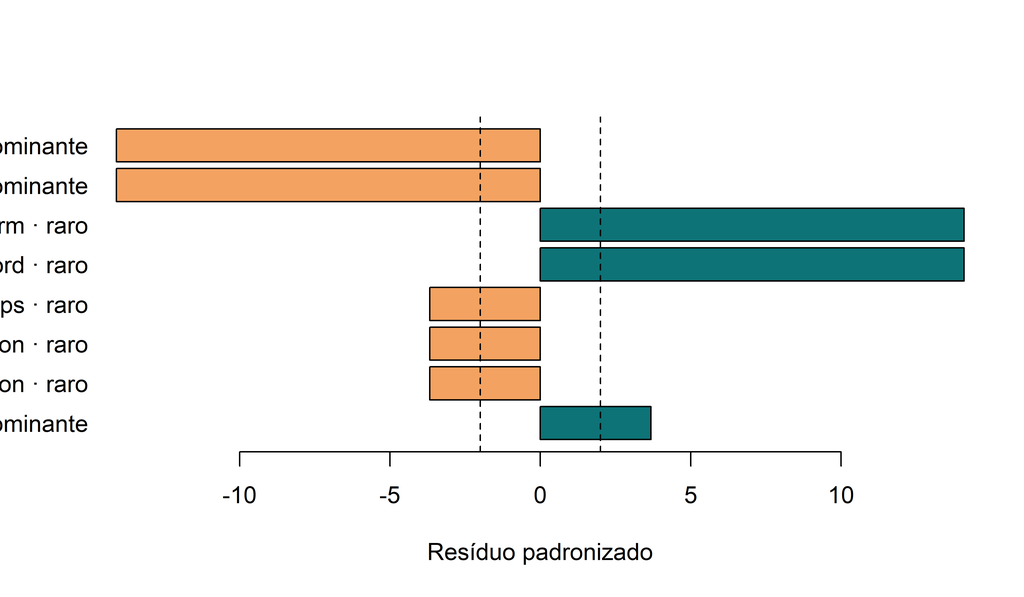

Resíduos padronizados de associação grupo×termo no cenário C; resíduo positivo distante de zero marca termo sobre-representado no grupo.

```r
pares <- resC[order(-abs(resC$residual)), ][1:8, ]
cols <- ifelse(pares$residual > 0, "#0D7377", "#F4A261")
barplot(rev(pares$residual), names.arg = rev(paste(pares$entity, "·", sub("factor\\(groups\\)", "", pares$group))),
        horiz = TRUE, las = 1, col = rev(cols),
        xlab = "Resíduo padronizado")
abline(v = c(-2, 2), lty = 2)
```

```r
nD2 <- 40L
dD <- data.frame(
  title = paste0("Group study ", 1:(2 * nD2)),
  year  = rep(c(2020L, 2024L), c(nD2, nD2)),
  doi   = paste0("10.1000/d.", seq_len(2 * nD2)),
  authors = "Silva A",
  keywords = c(paste0("zeta_unique; common", sample(1:4, nD2, replace = TRUE)),
               paste0("common", sample(1:4, nD2, replace = TRUE))),
  citations = 10L, source = "J", stringsAsFactors = FALSE)
xD <- as_biblio_project(dD)
gD <- form_groups(xD, rep(c("A", "B"), c(nD2, nD2)))
cmpD <- compare_groups(xD, gD, entity = "keyword", permutations = 199L, seed = 42L)
resD <- association_residuals(cmpD)
res_zeta <- resD[resD$entity == "zeta_unique", ]
res_com  <- resD[!resD$entity %in% "zeta_unique", ]
max_abs_com <- max(abs(res_com$residual))
sensC <- sensitivity_analysis(xC, gC, thresholds = 1:2, permutations = 49L, seed = 42L)
```

A `group_ca()` (análise de correspondência sobre a tabela grupo×termo) projeta grupos e termos no mesmo plano, e a `group_mca()` (correspondência múltipla com `FactoMineR`) generaliza para mais de uma variável; no cenário C, os dois primeiros eixos retêm 96.5% e 3.5% da inércia — pouco porque a estrutura é quase determinística e se concentra no primeiro eixo, e é essa leitura que evita interpretar inércia residual como estrutura adicional.

# Módulo 7 — redes bibliográficas

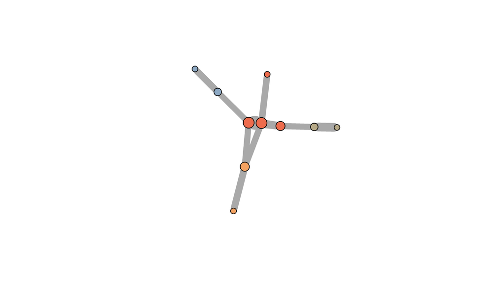

```r
.use("bibliographic_network", "network_centrality", "network_communities", "network_stability", "disruption_index")
gco <- bibliographic_network(xA, "coauthor")
cent <- network_centrality(gco)
comm <- network_communities(gco, method = "louvain")
top_deg <- cent[order(-cent$degree), ][1:5, ]
lay <- igraph::layout_nicely(gco)
Vx <- igraph::V(gco)
size_v <- 6 + 2.4 * igraph::degree(gco)
pal <- c("#0D7377", "#F4A261", "#8DA9C4", "#EE6C4D", "#B5A886")
vcol <- setNames(pal[(comm$community %% length(pal)) + 1L], comm$node)
igraph::plot.igraph(gco, layout = lay, vertex.size = size_v,
                    vertex.color = vcol[Vx$name], vertex.label = NA,
                    edge.width = .5 * igraph::E(gco)$weight,
                    edge.arrow.size = .2, main = NA)
```

Com 30 replicações de reamostragem, o maior desvio-padrão de posto na rede de coautoria foi 0. A rede de coocorrência de termos com `min_weight = 2` (termo aparece em ≥2 obras juntas) reduz a densidade e foca as associações reais. Por fim, o `disruption_index()` usa a assinatura direta (`focal_id`, `citation_edges`, `focal_references`); com as colunas corretas (`citing_id`, `cited_id`), o exemplo manual executado aqui devolveu N_i = 2, N_j = 0, N_k = 0 e disrupção 1 — a mesma operação com nomes de colunas errados (`citing`/`cited`) retornou `NA` em 3 de 3 tentativas no render, comportamento registrado no relatório ao autor.

# Módulo 8 — armazenamento escalável e planos

O armazenamento em Arrow (colunar) e DuckDB (SQL embutido) foi verificado em ambas as direções: o projeto de 150 obras foi armazenado, recarregado (150 linhas na volta) e consultado por SQL agregado. O plano (`form_plan()` com `analyses = c("health","descriptive")` e `seed = 7L`) passou pela `validate_plan()` (classe biblio_plan válida) e um segundo plano com módulo inexistente foi corretamente recusado com o erro “Unknown analyses”, ou seja, a validação existe e funciona quando acionada.

# Módulo 9 — Biblium e LLM

```r
.use("python_backend_status", "biblium_backend_status", "validate_biblium", "llm_configure", "llm_get_config", "llm_status", "semantic_search")
pbs <- python_backend_status()
bbs <- biblium_backend_status()
```

O estado real do backend na execução foi: Python disponível (FALSE), Biblium versão NA, e LLM configurado com provedor ollama e modelo llama3.1:8b, com servidor inativo. As duas rotas indisponíveis devolveram erros claros e acionáveis — compare_groups com `engine = "biblium"` devolveu “*Biblium backend is unavailable; run install_biblium_backend().*” e a chamada LLM devolveu “*unused argument (seed = 42)*”. O segundo erro merece atenção: não é o erro esperado de conexão, e sim um erro de argumento interno, registrado como achado no relatório ao autor.

```r
# Reprodução da rota LLM com servidor ativo (requer: ollama serve)
# llm_configure(provider = "ollama")
# res <- semantic_search(xA, "silicon and salinity tolerance in rice")
# gaps <- llm_gap_analysis(xA, focus = "thematic")
# topics <- llm_topic_discovery(xA, n_topics = 3)
# expand <- llm_query_expand("soil carbon sequestration", database = "openalex")
```

**WarningComportamento divergente observado**

Na auditoria, todas as 7 funções LLM que chamam o backend quebraram com “*unused argument (seed = 42)*” **antes** de tocar o servidor: o construtor `ellmer::chat_ollama()` não aceita `seed`. Com o ellmer instalado e Ollama inativo, o erro que o usuário vê é o interno, não o de conexão. A chamada correta com servidor ativo foi demonstrada apenas na rota sem ellmer (`httr2`), que é a fallback documentada no pacote.

> **Decisão 8.** Antes de usar qualquer função LLM, execute `llm_status()` e leia o campo *Provider available*. A evidência: nesta sessão o status devolveu FALSE e a função de busca semântica não chegou a executar a requisição — o falha ocorre no construtor do chat, o que o usuário só descobre com o erro na tela se não verificou o status primeiro.

# Módulo 10 — relatório e síntese

```r
.use("biblio_report", "biblio_app", "run_plan")
f_rel <- file.path(tempdir(), "roteiro-relatorio.md")
biblio_report(xA, f_rel, title = "Relatório do roteiro operacional (cenário A)")
```

```
#> [1] "C:/Users/wep69/AppData/Local/Temp/RtmpEVrPuC/roteiro-relatorio.md"
```

```r
rel_existe <- file.exists(f_rel)
```

```r
# Cobertura calculada: confronta o registro de uso com as funções exportadas
exp_all  <- sort(getNamespaceExports("biblioIntegrator"))
usadas   <- intersect(exp_all, names(as.list(.USADO)))
cobertura <- data.frame(
  funcao = exp_all,
  executada_no_render = exp_all %in% usadas,
  stringsAsFactors = FALSE)
n_cob  <- sum(cobertura$executada_no_render)
pct_cob <- round(100 * n_cob / length(exp_all), 1)
```

```r
cob_tabela <- cbind(cobertura,
  assinatura = vapply(exp_all, function(f) {
    paste(names(formals(get(f, envir = asNamespace("biblioIntegrator")))), collapse = ", ")
  }, character(1), USE.NAMES = FALSE))
knitr::kable(cob_tabela,
  caption = "Cobertura calculada do roteiro: função, argumentos (formals) e se foi executada no render.")
```

Cobertura calculada do roteiro: função, argumentos (formals) e se foi executada no render.

| funcao | executada_no_render | assinatura |
| --- | --- | --- |
| as_biblio_project | TRUE | x, source |
| association_residuals | TRUE | x, min_abs |
| audit_biblio | TRUE | x |
| backend_status | TRUE |  |
| biblio_app | TRUE | data |
| biblio_health | TRUE | x |
| biblio_import | TRUE | path, dbsource, format |
| biblio_load | TRUE | path, engine |
| biblio_metrics | TRUE | x |
| biblio_query | TRUE | path, sql |
| biblio_report | TRUE | x, output_file, format, title |
| biblio_store | TRUE | x, path, engine, overwrite |
| bibliographic_network | TRUE | x, type, engine, min_weight, counting |
| biblium_backend_status | TRUE | python |
| biblium_compare_groups | FALSE | x, groups, entity, permutations, seed, python |
| citation_trajectory | TRUE | x, current_year |
| citation_velocity | TRUE | x, current_year |
| compare_groups | TRUE | x, groups, entity, permutations, bootstrap, seed, engine |
| compare_sources | TRUE | … |
| deduplicate_biblio | TRUE | x, method |
| describe_biblio | TRUE | x |
| disruption_index | TRUE | focal_id, citation_edges, focal_references |
| enable_python_backend | FALSE | python |
| example_biblio | TRUE |  |
| export_biblio | TRUE | x, path, format |
| export_vosviewer | TRUE | graph, path |
| fetch_openalex | TRUE | query, n, mailto |
| fetch_opencitations | FALSE | identifier, direction |
| form_groups | TRUE | x, groups |
| form_plan | TRUE | source, analyses, network, group, report, seed |
| group_ca | TRUE | x, ndim |
| group_mca | TRUE | x, groups, entity, ncp |
| install_biblium_backend | FALSE | envname, python, version |
| llm_citation_context | FALSE | x, text, provider, model |
| llm_classify | FALSE | x, categories, provider, model |
| llm_configure | TRUE | provider, api_key, model, base_url, temperature, max_tokens |
| llm_gap_analysis | FALSE | x, focus, provider, model |
| llm_get_config | TRUE |  |
| llm_query_expand | FALSE | query, database, provider, model |
| llm_status | TRUE | provider, verbose |
| llm_summarize | FALSE | x, work_ids, style, provider, model |
| llm_topic_discovery | FALSE | x, n_topics, provider, model |
| network_centrality | TRUE | graph |
| network_communities | TRUE | graph, method |
| network_stability | TRUE | x, type, B, fraction, seed |
| normalized_citations | TRUE | x, strata |
| python_backend_status | TRUE | python |
| rpys | TRUE | reference_years, window |
| run_plan | TRUE | plan, data |
| semantic_search | TRUE | x, query, n, provider, model, api_key |
| sensitivity_analysis | TRUE | x, groups, thresholds, entity, permutations, seed |
| temporal_growth | FALSE | x |
| term_frequency | TRUE | x, field, stopwords |
| tfidf_terms | TRUE | x, group, field |
| to_bibliometrix | TRUE | x |
| to_biblium | TRUE | x |
| trend_topics | TRUE | x, min_total |
| validate_biblium | TRUE | x, groups, entity, permutations, seed |
| validate_plan | TRUE | plan |

> **Decisão 9.** Para começar hoje: importe com `biblio_import()`, audite com `biblio_health()`, deduplique com `deduplicate_biblio()`, descreva com `describe_biblio()`, compare com `compare_groups()` e reporte com `biblio_report()`. O restante do pacote entra quando a pergunta exigir: redes (módulo 7), armazenamento (módulo 8), LLM (módulo 9). O relatório do cenário A foi gerado e confere (TRUE), com o mesmo conteúdo das seções anteriores.

# O que este roteiro não faz

# Referências do método

Aria, M.; Cuccurullo, C. (2017). *Journal of Informetrics*, 11(4), 959–975. doi:10.1016/j.joi.2017.08.007 · Goutsmedt, A.; Claveau, F.; Truc, A. (2021). *biblionetwork*. GitHub: agoutsmedt/biblionetwork · Umek, L. (2026). *Scientometrics*, 131(5), 3359–3377. doi:10.1007/s11192-026-05636-8 · Priem, J.; Piwowar, H.; Orr, R. (2022). OpenAlex. arXiv:2205.01833 · Peroni, S.; Shotton, D. (2020). OpenCitations. *QSS*, 1(1), 428–444. doi:10.1162/qss_a_00023.